# Geospatial Risk Prediction

Minwook Kang

2022-10-21

## Ⅰ. Setup

This is section for libraries, functions and overall styling settings.

```r
# Rmarkdown global setting
knitr::opts_chunk$set(echo = TRUE)
knitr::opts_chunk$set(message = FALSE)
knitr::opts_chunk$set(warning = FALSE)
knitr::opts_chunk$set(cache = TRUE)
knitr::opts_chunk$set(fig.align = 'center')

#----------------------------------------------------------------------------------------------------------

# Import libraries
library(tidyverse)
library(tidycensus)
library(sf)
library(spdep)
library(caret)
library(ckanr)
library(FNN)
library(grid)
library(gridExtra)
library(ggcorrplot)# plot correlation plot
library(corrplot)
library(corrr)      # another way to plot correlation plot
library(kableExtra)
library(jtools)     # for regression model plots
library(ggstance) # to support jtools plots
library(ggpubr)    # plotting R^2 value on ggplot point scatter
library(broom.mixed) # needed for effects plots
library(knitr)
library(rmarkdown)
library(RSocrata)
library(viridis)
library(ggplot2)
library(stargazer)
library(XML)
library(data.table)
library(ggpmisc)
library(patchwork)
library(spatstat)
library(raster)
library(classInt)   # for KDE and ML risk class intervals
library(tableHTML)

#----------------------------------------------------------------------------------------------------------

# Temp
source("https://raw.githubusercontent.com/urbanSpatial/Public-Policy-Analytics-Landing/master/functions.r")
root.dir = "https://raw.githubusercontent.com/urbanSpatial/Public-Policy-Analytics-Landing/master/DATA/"

# Etc
options(scipen=999)
options(tigris_class = "sf")

#----------------------------------------------------------------------------------------------------------

# functions

st_c    <- st_coordinates
st_coid <- st_centroid

mapThememin <- function(base_size = 10, title_size = 12, small_size = 8) {
  theme(
    text = element_text( color = "black"),
    plot.title = element_text(size = title_size, colour = "black", hjust = 0.5),
    plot.subtitle=element_text(size = base_size, colour = "black", hjust = 0.5, face="italic"),
    plot.caption=element_text(size = small_size, colour = "black", hjust = 0.5),
    axis.ticks = element_blank(),
    axis.title = element_blank(),
    axis.text = element_blank(),
    axis.title.x = element_blank(),
    axis.title.y = element_blank(),
    panel.background = element_blank(),
    panel.grid.minor = element_blank(),
    panel.border = element_blank(),
    strip.text.x = element_text(size = small_size, face="italic"),
    strip.text.y = element_text(size = small_size, face="italic"),
    strip.background = element_rect(colour="transparent", fill="transparent"),
    legend.title = element_text(size = small_size),
    legend.text = element_text(size = small_size),
    legend.key.size = unit(0.4, "cm"))
}

mapThememin2 <- function(base_size = 8, title_size = 10, small_size = 6) {
  theme(
    text = element_text( color = "black"),
    plot.title = element_text(size = title_size, colour = "black", hjust = 0.5),
    plot.subtitle=element_text(size = base_size, colour = "black", hjust = 0.5, face="italic"),
    plot.caption=element_text(size = small_size, colour = "black", hjust = 0.5),
    axis.ticks = element_blank(),
    axis.title = element_blank(),
    axis.text = element_blank(),
    axis.title.x = element_blank(),
    axis.title.y = element_blank(),
    panel.background = element_blank(),
    panel.grid.minor = element_blank(),
    panel.border = element_blank(),
    strip.text.x = element_text(size = base_size),
    strip.text.y = element_text(size = base_size),
    strip.background = element_rect(colour="transparent", fill="transparent"),
    legend.title = element_text(size = small_size),
    legend.text = element_text(size = small_size),
    legend.key.size = unit(0.25, "cm"))
}


corTheme <- function(base_size = 10, title_size = 12, small_size = 8){
  theme(axis.text =  element_blank(),
        axis.ticks = element_blank(),
        text = element_text(size = 10),
        panel.background = element_rect(fill = greyPalette5[1]),
        axis.title.x = element_text(size = small_size),
        axis.title.y = element_text(size = small_size),
        plot.subtitle = element_text(hjust = 0.5, size = base_size),
        plot.title = element_text(hjust = 0.5, size = title_size),
        plot.caption=element_text(size = small_size, colour = "black", hjust = 0.5),
        strip.background = element_rect(colour="transparent", fill="transparent"))
}


corTheme2 <- function(base_size = 10, title_size = 12, small_size = 8){
  theme(axis.text =  element_text(size = small_size),
        text = element_text(size = 10),
        panel.background = element_rect(fill = greyPalette5[1]),
        axis.title.x = element_text(size = small_size),
        axis.title.y = element_text(size = small_size),
        plot.subtitle = element_text(hjust = 0.5, size = base_size,  face="italic"),
        plot.title = element_text(hjust = 0.5, size = title_size),
        plot.caption=element_text(size = small_size, colour = "black", hjust = 0.5),
        strip.background = element_rect(colour="transparent", fill="transparent"),
        strip.text.x = element_text(size = small_size, face="italic"),
        strip.text.y = element_text(size = small_size, face="italic"))
}

corTheme3 <- function(base_size = 9, title_size = 11, small_size = 7){
  theme(axis.text =  element_text(size = small_size),
        text = element_text(size = 10),
        panel.background = element_rect(fill = greyPalette5[1]),
        axis.title.x = element_text(size = small_size),
        axis.title.y = element_text(size = small_size),
        plot.subtitle = element_text(hjust = 0.5, size = base_size,  face="italic"),
        plot.title = element_text(hjust = 0.5, size = title_size),
        plot.caption=element_text(size = small_size, colour = "black", hjust = 0.5))
}

corTheme4 <- function(base_size = 9, title_size = 11, small_size = 7){
  theme(axis.text =  element_text(size = small_size),
        text = element_text(size = 10),
        panel.background = element_rect(fill = greyPalette5[1]),
        axis.title.x = element_text(size = small_size),
        axis.title.y.right = element_text(size = small_size),
        plot.subtitle = element_text(hjust = 0.5, size = base_size,  face="italic"),
        plot.title = element_text(hjust = 0.5, size = title_size),
        plot.caption=element_text(size = small_size, colour = "black", hjust = 0.5))
}


q5 <- function(variable) {as.factor(ntile(variable, 5))}

q <- function(variable) {as.factor(ntile(variable, 5))}

qBr <- function(df, variable, rnd) {
  if (missing(rnd)) {
    as.character(quantile(round(df[[variable]],0),
                          c(.01,.2,.4,.6,.8), na.rm=T))
  } else if (rnd == FALSE | rnd == F) {
    as.character(formatC(quantile(df[[variable]],
                                  c(.01,.2,.4,.6,.8), na.rm=T),
                         digits = 3))
  }
}

qBr2 <- function(df, variable, rnd) {
  if (missing(rnd)) {
    as.character(quantile(round(df[[variable]]*100,0)/100,
                          c(.01,.2,.4,.6,.8), na.rm=T))
  } else if (rnd == FALSE | rnd == F) {
    as.character(formatC(quantile(df[[variable]],
                                  c(.01,.2,.4,.6,.8), na.rm=T),
                         digits = 3))
  }
}

qBr3 <- function(df, variable, rnd) {
  if (missing(rnd)) {
    as.character(round(quantile(round(df[[variable]]*1000000,0),
                          c(.01,.2,.4,.6,.8), na.rm=T)),0)
  } else if (rnd == FALSE | rnd == F) {
    as.character(formatC(quantile(df[[variable]],
                                  c(.01,.2,.4,.6,.8), na.rm=T),
                         digits = 3))
  }
}

substrRight <- function(x, n){
  substr(x, nchar(x)-n+1, nchar(x))
}


nn_function <- function(measureFrom,measureTo,k) {
  measureFrom_Matrix <- as.matrix(measureFrom)
  measureTo_Matrix <- as.matrix(measureTo)
  nn <- get.knnx(measureTo, measureFrom, k)$nn.dist
  output <- as.data.frame(nn) %>%
    rownames_to_column(var = "thisPoint") %>%
    gather(points, point_distance, V1:ncol(.)) %>%
    arrange(as.numeric(thisPoint)) %>%
    group_by(thisPoint) %>%
    summarize(pointDistance = mean(point_distance)) %>%
    arrange(as.numeric(thisPoint)) %>%
    dplyr::select(-thisPoint) %>%
    pull()
  return(output)
}


myCrossValidate <- function(dataset, id, dependentVariable, indVariables) {

  allPredictions <- data.frame()
  cvID_list <- unique(dataset[[id]])

  for (i in cvID_list) {

    thisFold <- i
    cat("This hold out fold is", thisFold, "\n")

    fold.train <- filter(dataset, dataset[[id]] != thisFold) %>% as.data.frame() %>%
      dplyr::select(id, geometry, indVariables, dependentVariable)
    fold.test  <- filter(dataset, dataset[[id]] == thisFold) %>% as.data.frame() %>%
      dplyr::select(id, geometry, indVariables, dependentVariable)

    regression <-
      glm(countMVTheft ~ ., family = "poisson",
          data = fold.train %>%
            dplyr::select(-geometry, -id))

    thisPrediction <-
      mutate(fold.test, Prediction = predict(regression, fold.test, type = "response"))

    allPredictions <-
      rbind(allPredictions, thisPrediction)

  }
  return(st_sf(allPredictions))
}

#----------------------------------------------------------------------------------------------------------

# Colors ("https://coolors.co/gradient-palette/a8f368-f9035e?number=7")
bluePalette5 <- c("#eff3ff","#bdd7e7","#6baed6","#3182bd","#08519c")
blue2Palette5 <- c("#08519c","#3182bd","#6baed6","#bdd7e7","#eff3ff")
H_bluePalette5 <- c("#eff3ff","#bdd7e7","#6baed6","#3182bd","#252525")
orangePalette5 <- c("#FFF2E8","#FFD6B6","#FEB984","#FE9D51","#FD801F")
orange2Palette5 <- c("#FFDFD0","#FFB89F","#FF926E","#FF6B3D","#FF440C")
greyPalette5 <- c("#f7f7f7","#cccccc","#969696","#636363","#252525")
greenPalette5 <- c("#edf8e9","#bae4b3","#74c476","#31a354","#006d2c")
purplePalette5 <- c("#f2f0f7","#cbc9e2","#9e9ac8","#756bb1","#54278f")

#----------------------------------------------------------------------------------------------------------

# LoadAPI(Min's key)
census_api_key("4bbe4bead4e5817f6a6b79e62c5bea69e77f1887", overwrite = TRUE)
```

## Ⅱ. Data

Among the various crime data, Automobile theft (2018) was used as the variable to predict. Other risk factors utilized a total of six collected by the Chicago Public Data Portal (https://data.cityofchicago.org/)) and a 500*500ft fishnet Grid for prediction and analysis.

```r
#----------------------------------------------------------------------------------------------------------

# update to 2018 data

# some of risk factors data hasn't been updated yet after 2018

Criminals <- read.socrata("https://data.cityofchicago.org/Public-Safety/Crimes-2018/3i3m-jwuy")

#----------------------------------------------------------------------------------------------------------

# check criminal distributions

CriminalsType <- Criminals %>% dplyr::select(Primary.Type) %>% group_by(Primary.Type) %>% summarise(count = n())

CriminalsDescription <- Criminals %>% dplyr::select(Description) %>% group_by(Description) %>% summarise(count = n())

#----------------------------------------------------------------------------------------------------------



# Creating a fishnet grid

fishnet <-
  st_make_grid(chicagoBoundary,
               cellsize = 500,
               square = TRUE) %>%
  .[chicagoBoundary] %>%            # fast way to select intersecting polygons
  st_sf() %>%
  mutate(uniqueID = 1:n())
# Creating a fishnet grid

fishnet <-
  st_make_grid(chicagoBoundary,
               cellsize = 500,
               square = TRUE) %>%
  .[chicagoBoundary] %>%            # fast way to select intersecting polygons
  st_sf() %>%
  mutate(uniqueID = 1:n())


#----------------------------------------------------------------------------------------------------------

# Dependent variable : MOTOR VEHICLE THEFT - AUTOMOBILE

MVTheft <- Criminals %>%
  filter(Primary.Type == "MOTOR VEHICLE THEFT" & Description == "AUTOMOBILE") %>%
  mutate(x = gsub("[()]", "", Location)) %>%
  separate(x,into= c("Y","X"), sep=",") %>%
  mutate(X = as.numeric(X),Y = as.numeric(Y)) %>%
  dplyr::select(-Date, -Updated.On) %>%
  na.omit() %>%
  st_as_sf(coords = c("X", "Y"), crs = 4326, agr = "constant")%>%
  st_transform('ESRI:102271') %>%
  distinct()

MVTheft19 <-
  read.socrata("https://data.cityofchicago.org/Public-Safety/Crimes-2019/3i3m-jwuy") %>%
  filter(Primary.Type == "MOTOR VEHICLE THEFT" & Description == "AUTOMOBILE") %>%
  mutate(x = gsub("[()]", "", Location)) %>%
  separate(x,into= c("Y","X"), sep=",") %>%
  mutate(X = as.numeric(X),
         Y = as.numeric(Y)) %>%
  dplyr::select(-Date, -Updated.On) %>%
  na.omit %>%
  st_as_sf(coords = c("X", "Y"), crs = 4326, agr = "constant") %>%
  st_transform('ESRI:102271') %>%
  distinct() %>%
  .[fishnet,]


#----------------------------------------------------------------------------------------------------------

# 6 risk factors

# risk factor 1 of 6 : Abandoned cars

rf1_abandonCars <- read.socrata("https://data.cityofchicago.org/Service-Requests/311-Service-Requests-Abandoned-Vehicles/3c9v-pnva")

rf1 <- rf1_abandonCars %>%
    mutate(year = substr(creation_date,1,4)) %>% filter(year == "2018") %>%
    dplyr::select(Y = latitude, X = longitude) %>%
    na.omit() %>%
    st_as_sf(coords = c("X", "Y"), crs = 4326, agr = "constant") %>%
    st_transform(st_crs(fishnet)) %>%
    mutate(Legend = "Abandoned_Cars")

# risk factor 2 of 6 : Abandoned Buildings

rf2_abandonBuildings <- read.socrata("https://data.cityofchicago.org/Service-Requests/311-Service-Requests-Vacant-and-Abandoned-Building/7nii-7srd")

rf2 <- rf2_abandonBuildings %>%
    mutate(year = substr(date_service_request_was_received,1,4)) %>%  filter(year == "2018") %>%
    dplyr::select(Y = latitude, X = longitude) %>%
    na.omit() %>%
    st_as_sf(coords = c("X", "Y"), crs = 4326, agr = "constant") %>%
    st_transform(st_crs(fishnet)) %>%
    mutate(Legend = "Abandoned_Buildings")

# risk factor 3 of 6 : graffiti

rf3_graffiti <- read.socrata("https://data.cityofchicago.org/Service-Requests/311-Service-Requests-Graffiti-Removal-Historical/hec5-y4x5")

rf3 <- rf3_graffiti %>%
    mutate(year = substr(creation_date,1,4)) %>% filter(year == "2018") %>%
    filter(where_is_the_graffiti_located_ %in% c("Front", "Rear", "Side")) %>%
    dplyr::select(Y = latitude, X = longitude) %>%
    na.omit() %>%
    st_as_sf(coords = c("X", "Y"), crs = 4326, agr = "constant") %>%
    st_transform(st_crs(fishnet)) %>%
    mutate(Legend = "Graffiti")

# risk factor 4 of 6 : street Lights Out

rf4_streetLightsOut <- read.socrata("https://data.cityofchicago.org/Service-Requests/311-Service-Requests-Street-Lights-All-Out/zuxi-7xem")

rf4 <- rf4_streetLightsOut %>%
    mutate(year = substr(creation_date,1,4)) %>% filter(year == "2018") %>%
    dplyr::select(Y = latitude, X = longitude) %>%
    na.omit() %>%
    st_as_sf(coords = c("X", "Y"), crs = 4326, agr = "constant") %>%
    st_transform(st_crs(fishnet)) %>%
    mutate(Legend = "Street_Lights_Out")


# risk factor 5 of 6 : sanitation

rf5_sanitation <- read.socrata("https://data.cityofchicago.org/Service-Requests/311-Service-Requests-Sanitation-Code-Complaints-Hi/me59-5fac")

rf5 <- rf5_sanitation %>%
    mutate(year = substr(creation_date,1,4)) %>% filter(year == "2018") %>%
    dplyr::select(Y = latitude, X = longitude) %>%
    na.omit() %>%
    st_as_sf(coords = c("X", "Y"), crs = 4326, agr = "constant") %>%
    st_transform(st_crs(fishnet)) %>%
    mutate(Legend = "Sanitation")


# risk factor 6 of 6 : liquor Retail

rf6_liquorRetail <- read.socrata("https://data.cityofchicago.org/resource/nrmj-3kcf.json")

rf6 <- rf6_liquorRetail %>%
    filter(business_activity == "Retail Sales of Packaged Liquor") %>%
    dplyr::select(Y = latitude, X = longitude) %>%
    na.omit() %>%
    st_as_sf(coords = c("X", "Y"), crs = 4326, agr = "constant") %>%
    st_transform(st_crs(fishnet)) %>%
    mutate(Legend = "Liquor_Retail")

# risk factor A : Garbage Carts

rfA_garbageCarts <- read.socrata("https://data.cityofchicago.org/Service-Requests/311-Service-Requests-Garbage-Carts-Historical/9ksk-na4q")

rfA <- rfA_garbageCarts %>%
    mutate(year = substr(creation_date,1,4)) %>% filter(year == "2018") %>%
    dplyr::select(Y = latitude, X = longitude) %>%
    na.omit() %>%
    st_as_sf(coords = c("X", "Y"), crs = 4326, agr = "constant") %>%
    st_transform(st_crs(fishnet)) %>%
    mutate(Legend = "garbage_Carts")

# risk factor B : Alley light out

rfB_alleyLightsOut <- read.socrata("https://data.cityofchicago.org/Service-Requests/311-Service-Requests-Alley-Lights-Out-Historical/t28b-ys7j")

rfB <- rfB_alleyLightsOut %>%
    mutate(year = substr(creation_date,1,4)) %>% filter(year == "2018") %>%
    dplyr::select(Y = latitude, X = longitude) %>%
    na.omit() %>%
    st_as_sf(coords = c("X", "Y"), crs = 4326, agr = "constant") %>%
    st_transform(st_crs(fishnet)) %>%
    mutate(Legend = "alley_Light_sOut")
```

## Ⅲ. Process

### 1. Points & Fishnet Map of Automobile Theft

In the process of selecting a variable, selection bias can occur at any time. This is because, unlike the housing data used before, the existing crime data to be used for this learning is not complete. In other words, there may have been a bias in the process of generating this data in the first place. In fact, there is no way to check how many crimes will not be arrested, and the police may simply have arrested crimes in a biased way in a particular area. If this selective law enforcement is real, and if it’s reflected in the data we’re going to use, the model we’re going to create will eventually become a model that doesn’t generalize throughout space. Figure 1-1 maps the coordinates of the 2018 Automobile Theft, and Figure 1-2 reconstructs the entire Chicago into a 500*500ft mesh grid and visualizes how many Automobile Thefts occurred in each mesh. In future analysis, we will identify the hotspot of crime. And if you imagine that crime is spread out from this hotspot, you’ll get an intuition for the analysis follows.

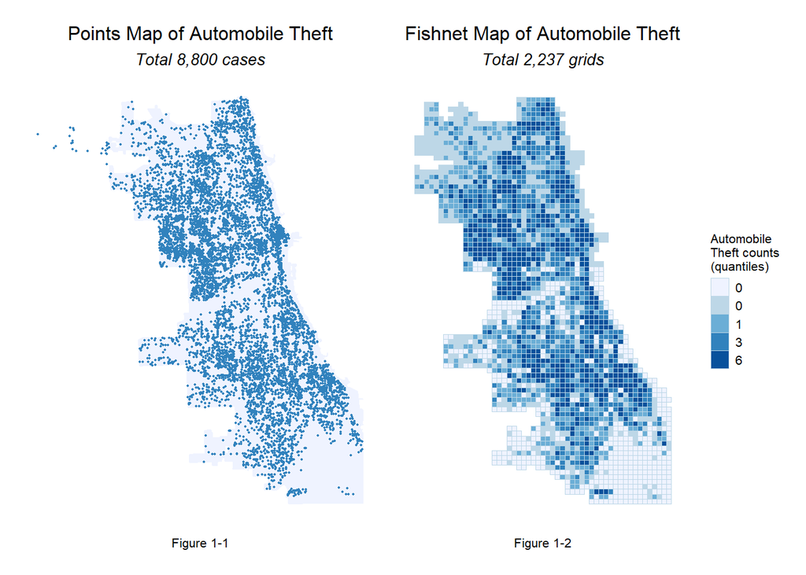

```r
crime_net <-
  dplyr::select(MVTheft) %>%
  mutate(countMVTheft = 1) %>%
  aggregate(., fishnet, sum) %>%
  mutate(countMVTheft = replace_na(countMVTheft, 0),
         uniqueID = 1:n(),
         cvID = sample(round(nrow(fishnet) / 24), size=nrow(fishnet), replace = TRUE)) # cross-validation id approx 100 folds

m1 <- ggplot() +
  geom_sf(data = chicagoBoundary, fill = bluePalette5[1], color = bluePalette5[1]) +
  geom_sf(data = MVTheft, colour=bluePalette5[4], size=0.3, show.legend = "point") +
  labs(title= "Points Map of Automobile Theft",
       subtitle = "Total 8,800 cases",
       caption = "Figure 1-1") +
  mapThememin()


m2 <- ggplot() +
  geom_sf(data = chicagoBoundary, fill = bluePalette5[1], color = "transparent", alpha = 0.5) +
  geom_sf(data = crime_net, aes(fill = q5(countMVTheft)), color = bluePalette5[2], size=0.00001) +
  scale_fill_manual(values = bluePalette5,
                    labels = qBr(crime_net, "countMVTheft"),
                    name = "Automobile\nTheft counts\n(quantiles)",
                    na.translate=FALSE) +
  labs(title = "Fishnet Map of Automobile Theft",
       subtitle = "Total 2,237 grids",
       caption = "Figure 1-2") +
  mapThememin()


m1+m2
```

### 2. Multiple Fishnet Maps of Risk Factors

A total of 6 types of risk factors were selected. Maps reassigned to the grid by averaging the distances from the center of each grid to the three nearest risk factors. The assumption of this analysis is that you can predict how much Automobile theft is exposed from each risk. In other words, the area with the closest distance is the area with the highest exposure.

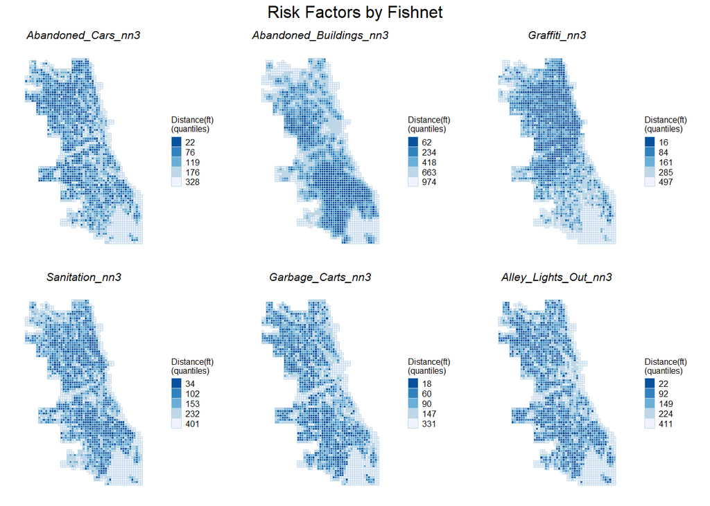

```r
vars_net <-
  rbind(rf1,rf2,rf3,rf5,rfA,rfB) %>%
  st_join(., fishnet, join=st_within) %>%
  st_drop_geometry() %>%
  group_by(uniqueID, Legend) %>%
  summarize(count = n()) %>%
    full_join(fishnet) %>%
    spread(Legend, count, fill=0) %>%
    st_sf() %>%
    dplyr::select(-`<NA>`) %>%
    na.omit() %>%
    ungroup()


vars_net <- vars_net %>%
    mutate(Abandoned_Cars_nn3 = round(nn_function(st_c(st_coid(vars_net)), st_c(rf1), k = 3)),
           Abandoned_Buildings_nn3 = round(nn_function(st_c(st_coid(vars_net)), st_c(rf2), k = 3)),
           Graffiti_nn3 = round(nn_function(st_c(st_coid(vars_net)), st_c(rf3), k = 3)),
           Sanitation_nn3 = round(nn_function(st_c(st_coid(vars_net)), st_c(rf5), k = 3)),
           Garbage_Carts_nn3 = round(nn_function(st_c(st_coid(vars_net)), st_c(rfA), k = 3)),
           Alley_Lights_Out_nn3 = round(nn_function(st_c(st_coid(vars_net)), st_c(rfB), k = 3)))

vars_net.nn <-
  dplyr::select(vars_net, ends_with("nn3")) %>%
    gather(Variable, value, -geometry)

vars <- unique(vars_net.nn$Variable)
mapList <- list()


for(i in vars){
  mapList[[i]] <-
    ggplot() +
    geom_sf(data = filter(vars_net.nn, Variable == i), aes(fill=q5(value)), color = bluePalette5[2], size=0.00000001) +
    scale_fill_manual(values = blue2Palette5,
                      labels = round(as.numeric(qBr(filter(vars_net.nn, Variable == i), "value")),0),
                      name = "Distance(ft)\n(quantiles)",
                      na.translate=FALSE) +
    labs(subtitle = i) +
  mapThememin2()
}

do.call(grid.arrange,c(mapList, ncol=3, top="Risk Factors by Fishnet"))
```

### 3. Local Moran’s I-related Maps

In this chapter, Local Moran’s I was used to check the degree of clustering at the regional scale. Here, the spatial weights were applied for nine pixels surrounding one pixel. Hotspot is a place with p-value 0 0.001 where the null hypothesis that Automobile Theft is randomly distributed regardless of the immediate vicinity can be rejected at a significant level.

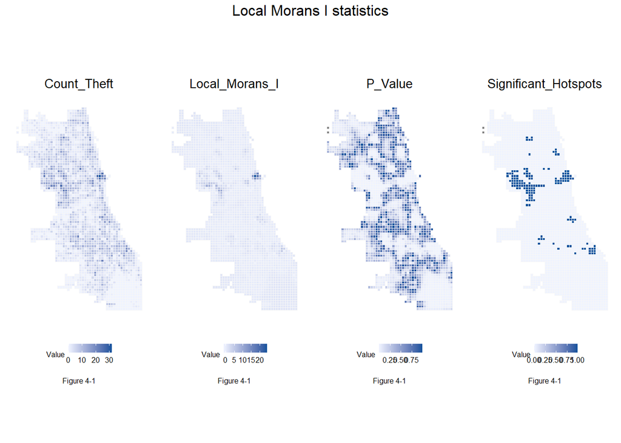

```r
#----------------------------------------------------------------------------------------------------------

final_net <-
  left_join(crime_net, st_drop_geometry(vars_net), by="uniqueID")

final_net <-
  st_centroid(final_net) %>%
    st_join(dplyr::select(neighborhoods, name)) %>%
    st_join(dplyr::select(policeDistricts, District)) %>%
      st_drop_geometry() %>%
      left_join(dplyr::select(final_net, geometry, uniqueID)) %>%
      st_sf() %>%
  na.omit()

#----------------------------------------------------------------------------------------------------------

final_net.nb <- poly2nb(as_Spatial(final_net), queen=TRUE)

final_net.weights <- nb2listw(final_net.nb, style="W", zero.policy=TRUE)

#----------------------------------------------------------------------------------------------------------

local_morans <- localmoran(final_net$countMVTheft, final_net.weights, zero.policy=TRUE) %>%
  as.data.frame()

#----------------------------------------------------------------------------------------------------------

# join local Moran's I results to fishnet
final_net.localMorans <-
  cbind(local_morans, as.data.frame(final_net)) %>%
  st_sf() %>%
  dplyr::select(Count_Theft = countMVTheft,
                Local_Morans_I = Ii,
                P_Value = `Pr(z != E(Ii))`) %>%
  mutate(Significant_Hotspots = ifelse(P_Value <= 0.001, 1, 0)) %>%
  gather(Variable, Value, -geometry)

#----------------------------------------------------------------------------------------------------------

vars2 <- unique(final_net.localMorans$Variable)
varList2 <- list()

for(i in vars2){
  varList2[[i]] <-
    ggplot() +
    geom_sf(data = filter(final_net.localMorans, Variable == i), aes(fill=Value), color = greyPalette5[1], size=0.01) +
    scale_fill_gradient(low = bluePalette5[1], high = bluePalette5[5]) +
    labs(title = i,
         caption = c("Figure 4-1", "Figure 4-2", "Figure 4-3", "Figure 4-4")) + theme(legend.position="bottom")+
    mapThememin2()}

do.call(grid.arrange,c(varList2, ncol = 4, top = "Local Morans I statistics"))
```

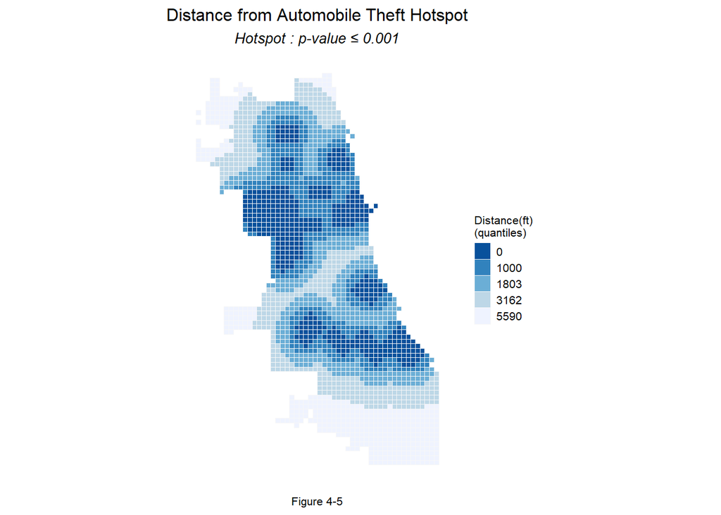

```r
#----------------------------------------------------------------------------------------------------------

final_net <-
  final_net %>%
  mutate(theft.isSig = ifelse(local_morans[,5] <= 0.001, 1, 0)) %>%
  mutate(theft.isSig.dist = nn_function(st_c(st_coid(final_net)), st_c(st_coid(filter(final_net, theft.isSig == 1))), k = 1))

ggplot() +
  geom_sf(data = final_net, aes(fill=q5(theft.isSig.dist)), color = greyPalette5[1], size=0.01) +
  scale_fill_manual(values = blue2Palette5,
                    labels = qBr(final_net, "theft.isSig.dist"),
                    name = "Distance(ft)\n(quantiles)",
                    na.translate=FALSE)+
  labs(title = "Distance from Automobile Theft Hotspot",
       subtitle = "Hotspot : p-value ≤ 0.001",
       caption = "Figure 4-5") +
  mapThememin()
```

### 4. Multiple Scatterplots with correlations

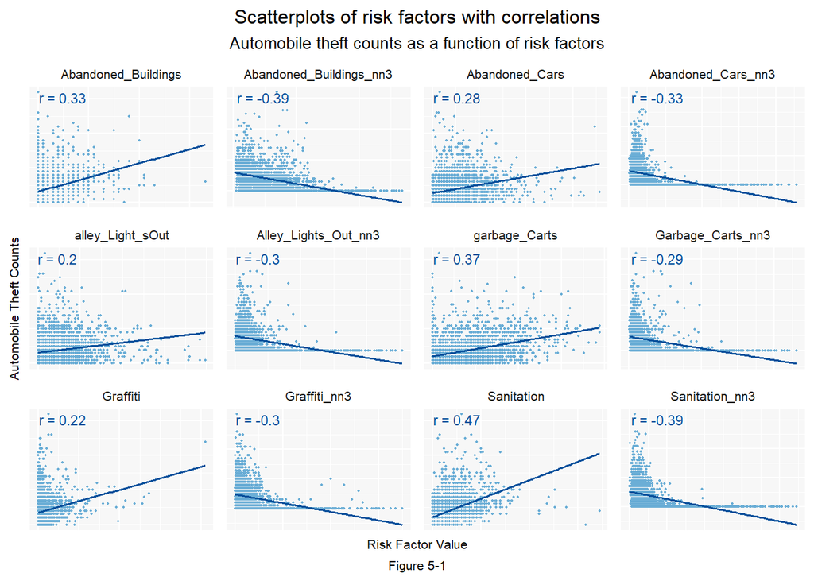

```r
correlation.long <-
  st_drop_geometry(final_net) %>%
    dplyr::select(-uniqueID, -cvID, -name, -District, -theft.isSig, -theft.isSig.dist) %>%
    gather(Variable, Value, -countMVTheft)

correlation.cor <-
  correlation.long %>%
    group_by(Variable) %>%
    summarize(correlation = cor(Value, countMVTheft, use = "complete.obs"))

ggplot(correlation.long, aes(Value, countMVTheft)) +
  geom_point(size = 0.3, color = bluePalette5[3])  +
  geom_text(data = correlation.cor, aes(label = paste("r =", round(correlation, 2))),
            x=-Inf, y=Inf, vjust = 1.5, hjust = -.2, size = 3, color = bluePalette5[5]) +
  geom_smooth(method = "lm", se = FALSE, colour = bluePalette5[5], size = 0.6) +
  facet_wrap(~Variable, ncol = 4, scales = "free") +
  labs(title = "Scatterplots of risk factors with correlations",
       subtitle = "Automobile theft counts as a function of risk factors",
       caption = "Figure 5-1",
       x = "Risk Factor Value",
       y = "Automobile Theft Counts") +
  corTheme()
```

### 5. A histogram of dependent variable

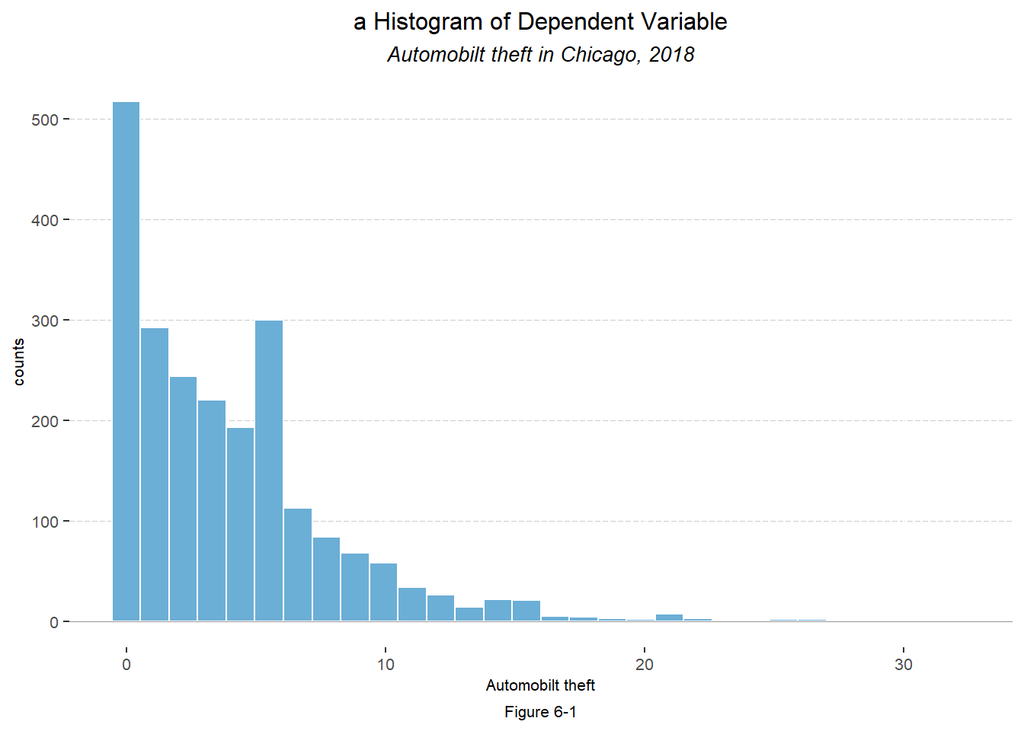

```r
ggplot(final_net, aes(x = countMVTheft))+
  geom_histogram(fill=bluePalette5[3], color = "white", size = 0.5, xlim=c(20,50))+
  labs(title = "a Histogram of Dependent Variable",
       subtitle = "Automobilt theft in Chicago, 2018",
       x = "Automobilt theft",
       y = "counts",
       caption = "Figure 6-1")+
  geom_hline(yintercept = 0, size = 0.25, color = greyPalette5[3]) +
  corTheme2()+
  theme(panel.background = element_blank(),
        panel.grid.major.y = element_line(linetype = "longdash", size = 0.25, color = greyPalette5[2]))
```

### 6. Maps of model errors

Figures that maps errors in the prediction model. If the error is not clustered, then the generalization of the prediction is greater. It can be visually confirmed that the degree of generalization of models using Hotspot is greater than that of models using only the Risk Factor.

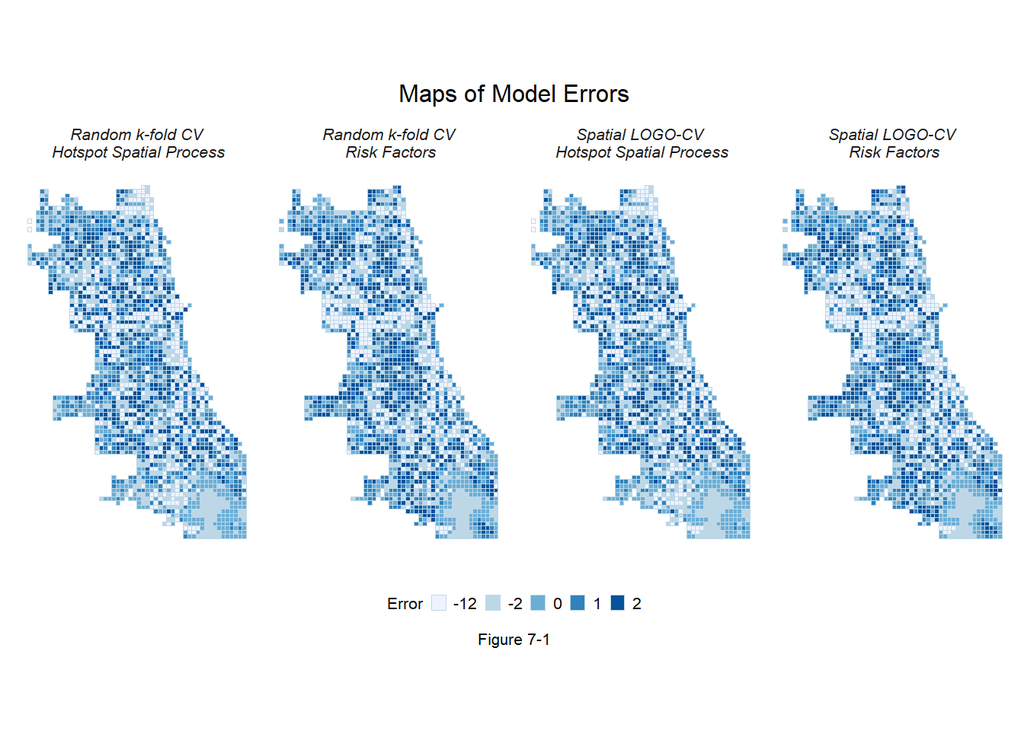

```r
ggplot(reg.summary) +
  geom_sf(aes(fill = q5(Error)), color = bluePalette5[2], size=0.00001) +
  scale_fill_manual(values = bluePalette5,
                    labels = qBr(reg.summary, "Error"),
                    name = "Error",
                    na.translate=FALSE) +
  labs(title = "Maps of Model Errors",
       caption = 'Figure 7-1') +
  facet_wrap(c(~Regression), ncol=4) +
  mapThememin() +
  theme(legend.position="bottom",
        legend.key.size = unit(0.25, "cm"))
```

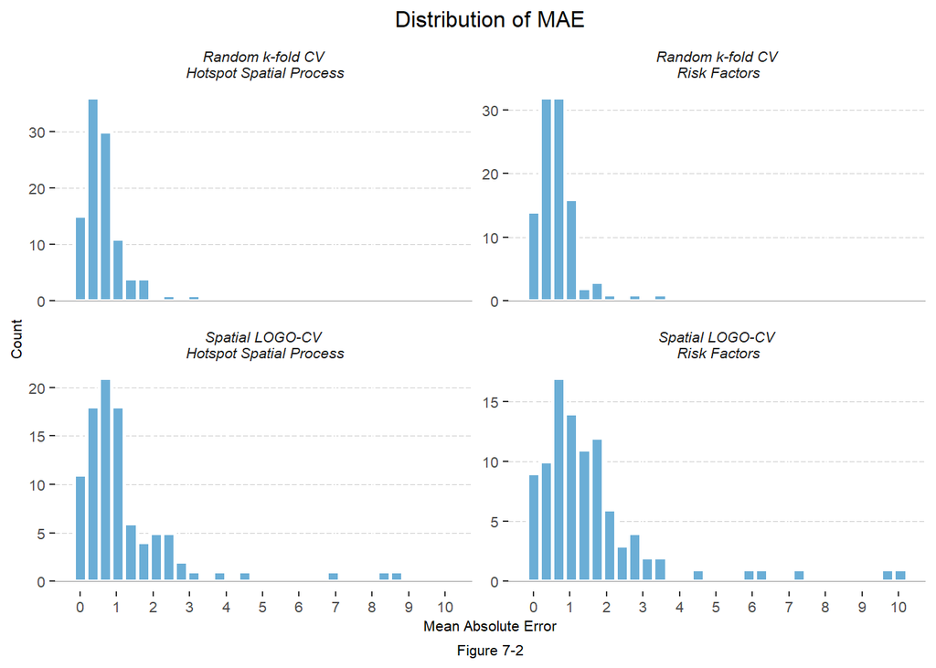

```r
error_by_reg_and_fold <-
  reg.summary %>%
    group_by(Regression, cvID) %>%
    summarize(Mean_Error = mean(Prediction - countMVTheft, na.rm = T),
              MAE = mean(abs(Mean_Error), na.rm = T),
              SD_MAE = mean(abs(Mean_Error), na.rm = T)) %>%
  ungroup()

error_by_reg_and_fold %>%
  ggplot(aes(MAE)) +
  geom_histogram(bins = 30,  color = "white", size = 1, fill=bluePalette5[3]) +
  facet_wrap(~Regression, scales = "free_y") +
  geom_hline(yintercept = 0, size = 0.25, color = greyPalette5[3]) +
  scale_x_continuous(breaks = seq(0, 12, by = 1)) +
  labs(title="Distribution of MAE",
       x="Mean Absolute Error", y="Count", caption = "Figure 7-2") +
  corTheme2() +
  theme(panel.background = element_blank(),
        panel.grid.major.y = element_line(linetype = "longdash", size = 0.25, color = greyPalette5[2]))
```

### 7. Table of MAE and standard deviation of MAE

Table 7-1 shows the size and distribution of the mean error, which is also an indicator that the degree of generalization of spatial models considering hotspots is greater.

```r
st_drop_geometry(error_by_reg_and_fold) %>%
  group_by(Regression) %>%
    summarize(Mean_MAE = round(mean(MAE), 2),
              SD_MAE = round(sd(MAE), 2)) %>%
  kable(caption = "<center><span style='font-size:14px; color: black; font-family: Arial;'>Table 7-1. MAE and standard deviation MAE by regression</span>", align = "c") %>%
    kable_minimal(full_width = T, html_font = "Arial", font_size = 15) %>%
    row_spec(2, color = greyPalette5[5], background = greyPalette5[1], bold = T) %>%
    row_spec(4, color = greyPalette5[5], background = greyPalette5[1], bold = T) %>%
    row_spec(0:4, extra_css = "line-height: 35px")
```

Table 7-1. MAE and standard deviation MAE by regression

| Regression | Mean_MAE | SD_MAE |
| --- | --- | --- |
| Random k-fold CV Hotspot Spatial Process | 0.61 | 0.53 |
| Random k-fold CV Risk Factors | 0.66 | 0.54 |
| Spatial LOGO-CV Hotspot Spatial Process | 1.22 | 1.49 |
| Spatial LOGO-CV Risk Factors | 1.62 | 1.76 |

### 8. Table of raw errors by race context

Table 8-1 also shows that the degree of generalization of spatial models considering hotspot is greater when viewed in RaceContext.

```r
raceContext <-
  reg.summary %>%
  st_centroid() %>%
  st_join(Chicago.tracts18) %>%
  na.omit() %>%
  st_drop_geometry() %>%
  group_by(Regression, raceContext) %>%
  summarize(mean.Error = mean(Error, na.rm = T)) %>%
  spread(raceContext, mean.Error) %>%
  kable(caption = "<center><span style='font-size:14px; color: black; font-family: Arial;'>Table 8-1. Mean Error by Neighborhood Racial Context</span>", align = "c") %>%
  kable_minimal(full_width = T, html_font = "Arial", font_size = 15) %>%
  row_spec(2, color = greyPalette5[5], background = greyPalette5[1], bold = T) %>%
  row_spec(4, color = greyPalette5[5], background = greyPalette5[1], bold = T) %>%
  row_spec(0:4, extra_css = "line-height: 35px")

raceContext
```

Table 8-1. Mean Error by Neighborhood Racial Context

| Regression | Majority_Non_White | Majority_White |
| --- | --- | --- |
| Random k-fold CV Hotspot Spatial Process | -0.2133149 | 0.2120363 |
| Random k-fold CV Risk Factors | -0.4186856 | 0.4242688 |
| Spatial LOGO-CV Hotspot Spatial Process | -0.2302555 | 0.2126365 |
| Spatial LOGO-CV Risk Factors | -0.4374532 | 0.4307875 |

### 9. Kernel Density Map vs Hotspot Risk Prediction Map

Figure 9-1 shows the location of the 2019 Automobile Theft above the Kernel Density Map and Hotspot Risk Prediction Map, which were created using data from 2018. Each map is divided into five categories according to the degree of risk, where 5th is the highest risk and 1th is the lowest risk.

```r
kde_breaks <- classIntervals(theft_KD.1000.df$value,n = 5, "fisher")

theft_KDE_sf <- theft_KD.1000.df %>%
  mutate(label = "Kernel Density Map\n from 2018 Data",
         Risk_Category = classInt::findCols(kde_breaks),
         Risk_Category = case_when(
           Risk_Category == 5 ~ "5th",
           Risk_Category == 4 ~ "4th",
           Risk_Category == 3 ~ "3th",
           Risk_Category == 2 ~ "2th",
           Risk_Category == 1 ~ "1th")) %>%
  cbind(aggregate(dplyr::select(MVTheft19) %>% mutate(theftCount = 1), ., sum) %>%
  mutate(theftCount = replace_na(theftCount, 0))) %>%
  dplyr::select(label, Risk_Category, theftCount)

#----------------------------------------------------------------------------------------------------------

ml_breaks <- classIntervals(reg.ss.spatialCV$Prediction,n = 5, "fisher")

theft_risk_sf <-
  reg.ss.spatialCV %>%
  mutate(label = "Hotspot Risk Predictions Map\n from 2018 Data",
         Risk_Category = classInt::findCols(ml_breaks),
         Risk_Category = case_when(
         Risk_Category == 5 ~ "5th",
           Risk_Category == 4 ~ "4th",
           Risk_Category == 3 ~ "3th",
           Risk_Category == 2 ~ "2th",
           Risk_Category == 1 ~ "1th")) %>%
  cbind(aggregate(dplyr::select(MVTheft19) %>% mutate(theftCount = 1), ., sum) %>%
  mutate(theftCount = replace_na(theftCount, 0))) %>%
  dplyr::select(label,Risk_Category, theftCount)
```

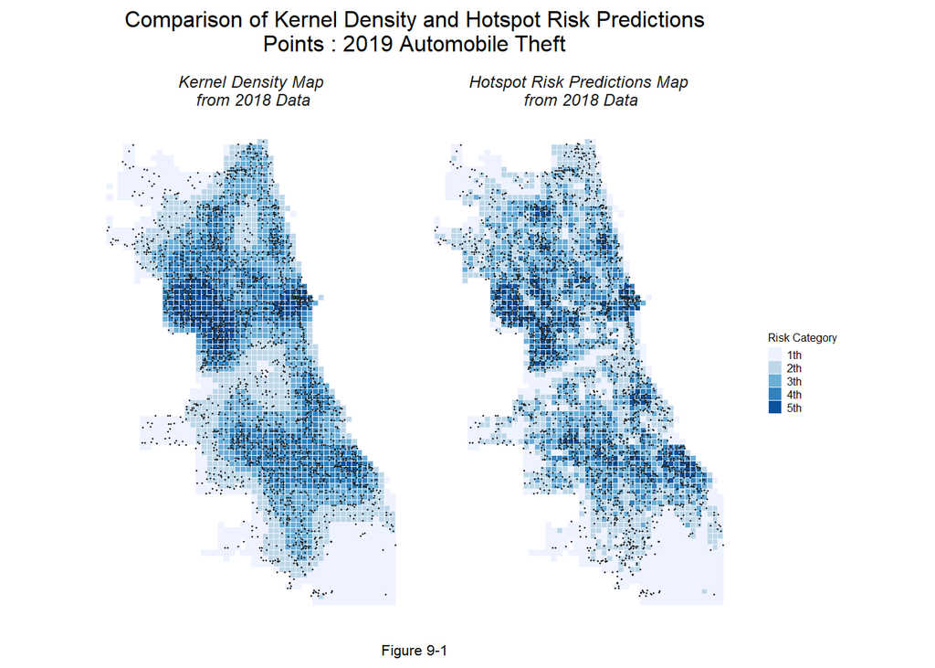

```r
theft_KDE_risk_sf <- rbind(theft_KDE_sf, theft_risk_sf) %>%
  na.omit() %>%
  gather(Variable, Value, -label, -Risk_Category, -geometry)


ggplot(theft_KDE_risk_sf) +
    geom_sf(aes(fill = Risk_Category), color = bluePalette5[1], size=0.0000001) +
    geom_sf(data = sample_n(MVTheft19, 3000), size = 0.25, color = greyPalette5[5]) +
    facet_wrap(~fct_rev(label), ) +
    scale_fill_manual(values = bluePalette5,
                      name = "Risk Category",
                      na.translate=FALSE) +
    labs(title="Comparison of Kernel Density and Hotspot Risk Predictions\nPoints : 2019 Automobile Theft",
         caption = "Figure 9-1") +
    mapThememin() + theme(strip.text.x = element_text(size = 9),
                        strip.text.y = element_text(size = 9),
                        legend.title = element_text(size = 6),
                        legend.text = element_text(size = 6),
                        legend.key.size = unit(0.25, "cm"))
```

### 10. The bar plot comparison

Figure 10-1 is a graph showing how many crimes were captured according to the risk categories in each model. The Kernel model has captured more crimes in the most at-risk 4th and 5th regions, meaning that the current model is not as useful as the Kernel model for predicting crimes.

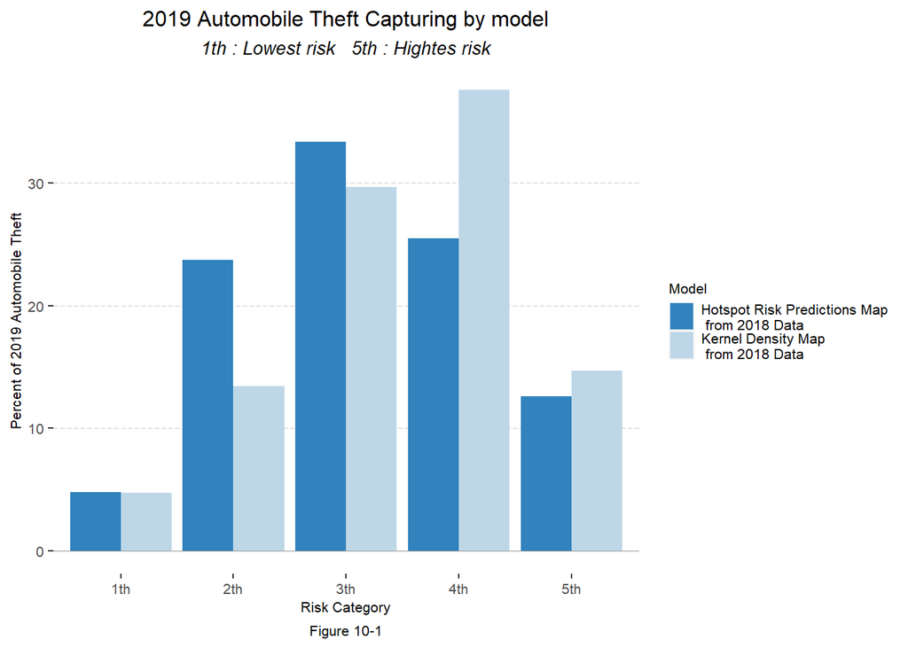

```r
theft_KDE_risk_sf %>%
  group_by(label, Risk_Category) %>%
  summarize(countTheft = sum(Value)) %>%
  ungroup() %>%
  group_by(label) %>%
  mutate(Pcnt_of_test_set_crimes = countTheft / sum(countTheft)*100) %>%
    ggplot(aes(Risk_Category,Pcnt_of_test_set_crimes)) +
      geom_bar(aes(fill=label), position="dodge", stat="identity") +
      scale_fill_manual(values = c(bluePalette5[4],bluePalette5[2]), name = rev("Model")) +
      labs(title = "2019 Automobile Theft Capturing by model",
           subtitle = "1th : Lowest risk   5th : Hightes risk",
           y = "Percent of 2019 Automobile Theft",
           x = "Risk Category",
           caption = "Figure 10-1")  +
    geom_hline(yintercept = 0, size = 0.25, color = greyPalette5[3]) +
    corTheme2()+
    theme(panel.background = element_blank(),
          panel.grid.major.y = element_line(linetype = "longdash", size = 0.25, color = greyPalette5[2]),
          legend.title = element_text(size = 8),
          legend.text = element_text(size = 8),
          legend.key.size = unit(0.5, "cm"))
```

## Ⅳ. Conclustion

While we were able to confirm that models using Hotspot have a high degree of generalization, we have not shown good results in capturing crimes in high-risk areas. Even if you’ve shown good results, you can’t be sure that the real model is not biased. Therefore, it would be desirable to use a model that predicts this risk for events such as fires that do not bias real data collection.